# Graded Assignment: Data Analysis Project

Bayesian Statistics Specialization: Course 2, Techniques and Models

Tiago B. Lacerda

2025-05-11

# Executive Summary

This report presents a comprehensive analysis of the Excellent Consistent Quality (ECQ) success rate across various network sites in Brazil’s Northeast region. The primary objective is to identify sites with significantly lower ECQ success probabilities compared to the network average, enabling targeted interventions for network improvement. A three-level Bayesian hierarchical model is employed to account for data scarcity and local variability, providing stable estimates of each site’s true ECQ success probability. The analysis reveals critical insights into site performance, guiding data-informed investment decisions.

# Introduction

### Problem Definition

Our network comprises multiple sites scattered across a city, each running a varying number of ECQ tests. Some sites may report as few as 5–20 tests in a given period, while others conduct several hundred. The core challenge is to identify which sites genuinely underperform in terms of ECQ success rate and thus prioritize network improvement investments, without being misled by the randomness inherent in small test counts.

#### Specific Question

> *Which sites have a true ECQ success probability significantly below the network average, and how can rank them for targeted interventions, accounting for both data scarcity and local variability?*

By formalizing this question, we set the stage for applying a hierarchical Bayes model that “borrows strength” across sites and municipalities, producing posterior distributions for each site’s success probability. These posteriors underpin credible intervals and ranking metrics that guide robust, data-informed investment decisions.

### Data

In this report, we analyze ECQ test data collected in October 2024 across Brazil’s Northeast region, encompassing 8 ANFs. Each data point corresponds to a specific network site, identified by its unique ENDERECO_ID. For every site, we have recorded the total number of ECQ tests conducted and the number of successful tests (TESTES_ECQ_OK), indicating instances where the network met the stringent performance thresholds defined by the ECQ metric.

Below is a summary of the data we will be using in our analysis.

```
## tibble [958 × 6] (S3: tbl_df/tbl/data.frame)
##  $ group_id     : int [1:958] 101 103 93 106 104 107 95 96 94 97 ...
##  $ ANF          : chr [1:958] "83" "83" "83" "83" ...
##  $ MUNICIPIO    : chr [1:958] "ARACAGI" "ARARUNA" "AGUA BRANCA" "AREIAL" ...
##  $ ENDERECO_ID  : chr [1:958] "PBAAG_0001" "PBAAN_0001" "PBABW_0001" "PBAEA_0001" ...
##  $ TESTES_ECQ_OK: num [1:958] 9 27 12 10 80 0 19 5 26 0 ...
##  $ TESTES_ECQ   : num [1:958] 13 57 28 12 150 1 21 12 31 12 ...
```

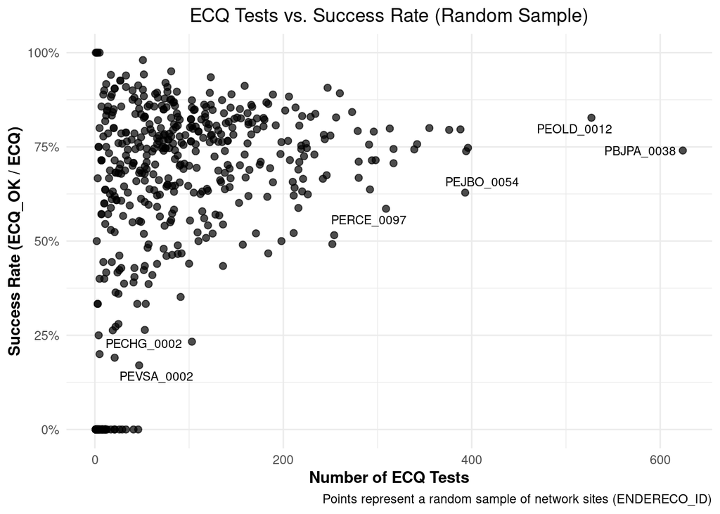

## Bayesian Model Structure

Model structure definition in JAGS.

```r
model_string <- "
model {
  # Hiperparâmetros globais
  mu_global ~ dbeta(3, 3)
  sigma_global ~ dgamma(2, 0.5)  # Prior Gamma mais informativa

  # Parâmetros ANF com restrição
  alpha_anf <- mu_global * sigma_global
  beta_anf <- (1 - mu_global) * sigma_global
  mu_anf ~ dbeta(alpha_anf, beta_anf)

  # Priors para dispersão
  phi_municipio ~ dgamma(2, 0.9)  # Gamma mais suave
  phi_site ~ dgamma(2, 2)

  # Loop por municípios
  for(g in 1:N_group) {
    a_municipio[g] <- mu_anf * phi_municipio
    b_municipio[g] <- (1 - mu_anf) * phi_municipio
    mu_municipio[g] ~ dbeta(a_municipio[g], b_municipio[g])
  }

  # Loop por sites
  for(s in 1:N_sites) {
    logit_mu_site[s] <- logit(mu_municipio[group_per_site[s]])
    theta_site[s] <- ilogit(logit_mu_site[s] + epsilon[s])
    epsilon[s] ~ dnorm(0, 1/phi_site)

    n_success[s] ~ dbin(theta_site[s], n_tests[s])
  }
}
"
```

### Conclusions

In summary, the Bayesian hierarchical model provides a comprehensive framework for identifying underperforming areas and supports evidence-based decision-making to enhance overall network quality.